# Operaciones Básicas en R

Benjamín Muñoz

25/04/2020

Ahora analizaremos las operaciones fundamentales para trabajar con R. El punto de partida es tener claridad que R es un software basado en programación orientado a objetos (POO). Un objeto es una estructura de datos que permite el almacenamiento de información. En POO los objetos tienen **clases** que los definen específicamente. Los **métodos** son funciones especializadas para desarrolllar cálculos específicos aprovechando las particularidades de la clase del objeto. Los objetos en R pueden ser reutilizados y relacionados entre sí. Si desean aprender más sobre estos temas, revisen la definición de [CRAN](https://cran.r-project.org/doc/manuals/r-release/R-lang.html) y el libro [Advanced R](http://adv-r.had.co.nz/).

R funciona como **command line interface** o interfaz de línea de comandos. Es decir, el usuario interactúa con R por medio de instrucciones que siguen reglas sintácticas. Esto se hace en la **Consola** de R. El símbolo `>` corresponde al prompt, dónde se ingresan comandos para interactuar con R.

[figure not shown]

A continuación estudiaremos:

- Operaciones aritméticas básicas.
- Asignación para generar nuevos objetos.
- Combinación para combinar elementos y/u objetos.
- Indexación para extraer elementos según su posición.
- Uso de funciones.

## Operaciones Aritméticas

Primeramente revisaremos como se ingresan valores en R. Por defecto R utiliza el punto como símbolo de separación de decimales y la notación científica para representar valores. Para ingresar valores, sólo debemos hacerlo en el prompt:

```r
#Ingreso de valores
1
```

```
## [1] 1
```

```r
-222222222222           #No hay separador de miles en R.
```

```
## [1] -222222222222
```

```r
1.50000000000000        #El punto es el separador de decimales.
```

```
## [1] 1.5
```

```r
0.000000000000000000095 #R usa por defecto notacion cientifica para valores extremadamente grandes o pequeños.
```

```
## [1] 9.5e-20
```

```r
options(scipen=999)    #Con este comando modificamos el uso de notación científica.
                       #Indicamos que use notación científica con números que contengan 999 dígitos.

0.000000000000000000095
```

```
## [1] 0.000000000000000000095
```

A su vez, en R se pueden realizar todas las operaciones ariméticas:

| Operación | Símbolo |
| --- | --- |
| Suma | + |
| Resta | - |
| Multiplicación | * |
| División | / |
| Potencia | ** ó ^ |

Ahora podemos entender cómo opera R: al ingresar código a la Consola (en el prompt) se ingresa una instrucción sobre qué realizar con datos, la cual es enviada al CPU para que sea calculada y luego se retorna el resultado, el cual aparece después de `[1]`.

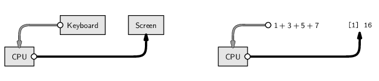

```r
#Adición
2 + 3
```

```
## [1] 5
```

```r
#Sustracción
2 - 3
```

```
## [1] -1
```

```r
#Multiplicación
2*3
```

```
## [1] 6
```

```r
#División
2/3
```

```
## [1] 0.6666667
```

```r
#Exponenciación
2^3
```

```
## [1] 8
```

```r
2**3
```

```
## [1] 8
```

Las divisiones no exactas -el resto de la división no es cero- dan lugar a otras operaciones básicas:

```r
#División no exacta
9/2
```

```
## [1] 4.5
```

```r
#División entera: determina el cociente entero de una división no exacta (sin decimales)
9%/%2
```

```
## [1] 4
```

```r
#Modular: determina el resto de una división no exacta
9%%2
```

```
## [1] 1
```

R sigue las reglas de prioridad de las operaciones matemáticas. Si quieres revisar información sobre esto entra a este [link](https://es.wikipedia.org/wiki/Orden_de_evaluaci%C3%B3n). En vista de lo anterior, es importante usar paréntesis:

```r
(4 + 3)^2
```

```
## [1] 49
```

```r
4 + 3^2
```

```
## [1] 13
```

Si una operación se divide en dos líneas de código, la separación entre la primera y la segunda línea debe hacerse por medio del símbolo/operador matemático:

```r
2+3*4+(36/6)+48-13*2+(2*3*6/9+15-27+12*3)
```

```
## [1] 70
```

```r
2+3*4+(36/6)+48-13*2+
  (2*3*6/9+15-27+12*3)
```

```
## [1] 70
```

```r
2+3*4+(36/6)+48-13*2
```

```
## [1] 42
```

```r
+(2*3*6/9+15-27+12*3)
```

```
## [1] 28
```

## Asignación

La asignación es la operación por medio de la cual se genera un objeto en R. Existen 5 símbolos para realizar esto:

| Nombre | Símbolo |
| --- | --- |
| Flecha izquierda simple: | <- |
| Flecha derecha simple: | -> |
| Flecha izquierda doble: | <<- |
| Flecha derecha doble: | ->> |
| Igualdad: | = |

El resultado de la operación de asignación es la generación de un objeto, el cual aparece en el espacio de R *Global Environment* (ventana superior derecha en RStudio). No debería aparecer impreso un output en la Consola. Para revisar un objeto, el modo más sencillo es tipear su nombre y ejecutarlo en la Consola. Otra alternativa es utilizar `print()`:

```r
#Asignación

a1 <- 5
a1
```

```
## [1] 5
```

```r
10 -> a2
a2
```

```
## [1] 10
```

```r
a3 <<- 15
a3
```

```
## [1] 15
```

```r
20 ->> a4
a4
```

```
## [1] 20
```

```r
a5 = 25
print(a5)
```

```
## [1] 25
```

No obstante existen cinco símbolos para asignar, **se recomienda utilizar únicamente** `<-` en nuestro trabajo en R. No sólo es por criterios de [estilo](http://adv-r.had.co.nz/Style.html) al generar código, sino que tiene un [alcance](http://adv-r.had.co.nz/Functions.html#lexical-scoping) más adecuado en la generación de objetos y su almacenamiento en R y sus [ambientes](http://adv-r.had.co.nz/Environments.html). Un ejemplo sencillo de las diferencias entre operadores de asignación la puedes encontrar [aquí](http://www.studytrails.com/r/core/assignmentoperator/).

```r
b <--2
b
```

```
## [1] -2
```

```r
c <- -2  #Al incluir un espacio se facilita la lectura
c
```

```
## [1] -2
```

El uso de espacios es recomendable para facilitar la lectura del código, pero no pueden existir espacios entre el símbolo `<` y `-` al momento de formar la flecha. Si no se cumple, esto da lugar a errores:

```r
d<-0.5
d
```

```
## [1] 0.5
```

```r
d< -0.5
```

```
## [1] FALSE
```

Los nombres de los objetos pueden incluir letras minúsculas y/o mayúsculas, números y algunos símbolos como puntos y guiones bajos. No hay restricciones de longitud. El nombre del objeto **no puede comenzar con un número**:

```r
numero_muy.importante <- 3
numero_muy.importante

2a <- 2 #Arroja un error ya que el nombre inicia con un número
```

```
## Error: <text>:4:2: unexpected symbol
## 3:
## 4: 2a
##     ^
```

Por último, R es **caso sensitivo**, distinguiendo entre minúsculas y mayúsculas (los trata como objetos distintos) y no existen atajos para escribir funciones:

```r
x1 <- 12
x1
```

```
## [1] 12
```

```r
X1   #Arroja error ya que aparece una mayúscula
```

```
## Error in eval(expr, envir, enclos): object 'X1' not found
```

## Combinación

La función `c()` permite combinar elementos y/u objetos:

```r
#Combinar elementos sin construir un objeto

c(1,2,3,4,5)
```

```
## [1] 1 2 3 4 5
```

```r
#Combinar elementos al construir un objeto

f <- c(1,2,3,4,5,6,7,8,9,10)
f
```

```
##  [1]  1  2  3  4  5  6  7  8  9 10
```

```r
#Combinar elementos y objetos al construir un objeto

g <- c(f,12,14,16)
g
```

```
##  [1]  1  2  3  4  5  6  7  8  9 10 12 14 16
```

El error más frecuente al utilizar combinación está en el uso inadecuado de las comas como separadores de los objetos/elementos:

```r
f1 <- c(1,2,3,4,5,6,7,8,9,10,)
```

```
## Error in c(1, 2, 3, 4, 5, 6, 7, 8, 9, 10, ): argument 11 is empty
```

```r
f1
```

```
## Error in eval(expr, envir, enclos): object 'f1' not found
```

Se pueden realizar operaciones con objetos combinados, pero la longitud del objeto (el número de elementos incluidos en su interior) es **muy importante**. Veamos un ejemplo sencillo con operaciones aritméticas:

```r
alfa <- c(1,2,3)    #El objeto contiene 3 elementos.
beta <- c(5,10,15)  #El objeto contiene 3 elementos.
gamma <- c(2,6)     #El objeto contiene 2 elementos.

alfa*beta
```

```
## [1]  5 20 45
```

```r
alfa*gamma
```

[output not shown]

## Indexación

En R, los elementos contenidos al interior de un objeto están ordenados. Por lo tanto, cuentan con una posición específica (existe un indicador de su posición al interior del objeto). Al evaluar el objeto g no sólo obtenemos un 4, si no que también a su izquierda aparece un paréntesis cuadrado `[1]`. Esto indica que el primer elemento dentro de g es un 4. Al inicio de cada línea de output de R podrán observar el valor respectivo del vector de posición.

```r
g <- 4
g
```

```
## [1] 4
```

```r
h <- c(2,4,6,8,10,12,14,16,18,20,22,24,26,28,30,32,34,36,38,40,42,44,46,48,50,52,54,56,58,60,62,64,66,68,70,72,74,76,78,80,82,84,86)
h
```

```
##  [1]  2  4  6  8 10 12 14 16 18 20 22 24 26 28 30 32 34 36 38 40 42 44 46 48 50
## [26] 52 54 56 58 60 62 64 66 68 70 72 74 76 78 80 82 84 86
```

La posición puede ser utilizada para realizar ciertas acciones en R. El paréntesis cuadrado permite encontrar los elementos dentro de un objeto:

```r
#nombre.de.objeto[i]


h[1]         #Extrae el 1er elemento
```

```
## [1] 2
```

```r
h[10]        #Extrae el 10mo elemento
```

```
## [1] 20
```

```r
h[c(2,4,6)]  #Extrae el 2do, 4to y 6to elemento.
```

```
## [1]  4  8 12
```

```r
#El uso de un índice negativo, del tipo [-i], busca todos los valores a excepción del indicado (i).

h[-3]
```

```
##  [1]  2  4  8 10 12 14 16 18 20 22 24 26 28 30 32 34 36 38 40 42 44 46 48 50 52
## [26] 54 56 58 60 62 64 66 68 70 72 74 76 78 80 82 84 86
```

```r
#La indexación puede ser usada para reemplazar algún valor:

h[1]
```

```
## [1] 2
```

```r
h[1]<-100
h[1]
```

```
## [1] 100
```

## Uso de Funciones

Las funciones en R permiten tomar elementos y/u objetos como inputs para aplicarles procedimientos y entregar detetrminados outputs. La lógica de una función es simplificar los pasos necesarios para ejecutar algún proceso:

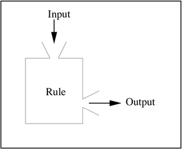

Existen en R funciones que permiten realizar distintos procedimientos sobre los objetos de R. De manera sencilla, hay tres tipos:

1. Funciones built-in
2. Funciones incorporadas en paquetes
3. Funciones definidas por el usuario

Las funciones built-in se encuentran disponibles en R de manera inmediata, mientras que las incorporadas por paquetes requieren que éstos previamente estén instalados y activados. Por último, el usuario puede elaborar funciones propias. Las funciones contienen argumentos, los cuales permiten identificar los objetos/elementos considerados como inputs y ajustar el resultado de la función.

Las funciones también son objetos y pueden ser argumentos de otras funciones. Aún más, las funciones pueden anidarse entre sí.

Hay argumentos que son obligatorios, por lo que si no son ingresados, la función no podrá ejecutarse ni generar un output. Otros argumentos son optativos y no deben ser incluidos. Por último, en ocasiones los argumentos de las funciones pueden tener valores por defecto. Para chequear los argumentos de una función se debe revisar la ayuda asociada ``?```.

```r
#Calcular la media de un objeto:

i <- c(2,4,6,8,10,12,14,16,18,20,22,24,25)
i
```

```
##  [1]  2  4  6  8 10 12 14 16 18 20 22 24 25
```

```r
mean()   #La función arroja un error ya que tiene argumentos obligatorios que no fueron introducidos
```

```
## Error in mean.default(): argument "x" is missing, with no default
```

```r
#Buscar ayuda sobre una función
?mean
args(mean)
## function (x, ...)
## NULL

#mean(x, trim=0, na.rm=FALSE)
#El argumento x es obligatorio, se necesita un objeto de R para evaluar la función.
#En cambio, los otros dos argumentos no son obligatorios
mean(i)
```

```
## [1] 13.92308
```

```r
mean(i,trim=0,na.rm=FALSE)
```

```
## [1] 13.92308
```

```r
mean(i,trim=0.5)
```

```
## [1] 14
```

Existen muchas funciones de uso frecuente en R. Si tienen dudas sobre su uso, busquen cuáles son sus argumentos. Veamos algunas funciones:

```r
#Valor absoluto
abs(-4)
```

```
## [1] 4
```

```r
#Raíz Cuadrada
sqrt(16)
```

```
## [1] 4
```

```r
#Logaritmo (por defecto con base natural)
log(10)
```

```
## [1] 2.302585
```

```r
#Logaritmo con base 10
log10(10)
```

```
## [1] 1
```

```r
#Exponencial
exp(2.302585)
```

```
## [1] 9.999999
```

```r
#Redondear números
round(9.999)
```

```
## [1] 10
```

```r
round(7.12345,digits = 2)
```

```
## [1] 7.12
```

```r
#Truncar números
trunc(5.4)
```

```
## [1] 5
```

```r
#Secuencia de valores
0:10
```

```
##  [1]  0  1  2  3  4  5  6  7  8  9 10
```

```r
seq(from=0,to=10,by=1)
```

```
##  [1]  0  1  2  3  4  5  6  7  8  9 10
```

```r
seq(0,10,1)
```

```
##  [1]  0  1  2  3  4  5  6  7  8  9 10
```

```r
#Repetir valores
rep(x=5,times=10)
```

```
##  [1] 5 5 5 5 5 5 5 5 5 5
```

```r
rep(1:3,2)
```

```
## [1] 1 2 3 1 2 3
```

```r
#Listar objetos presentes en el área de trabajo
ls()
```

```
##  [1] "a1"    "a2"    "a3"    "a4"    "a5"    "alfa"  "b"     "beta"  "c"
## [10] "d"     "f"     "g"     "gamma" "h"     "i"     "x1"
```

```r
#Remover objetos presentes en el área de trabajo
rm()

#Podemos combinar ambos comandos para eliminar todos los objetos en
#el área de trabajo
rm(list=ls())

ls() #Chequeemos si todos fueron eliminados.
## character(0)
```